# Nova-Report

Neuzugänge im SLUB-Katalog

2026-02-03

GitHub-Repository: slub/nova-report  
Zenodo-Community: [SLUB Nova](https://zenodo.org/communities/slub-nova/records) (`slub-nova`)

# Suchserver

## Indexierungen

### Kennzahlen

#### 2022–2025

Gesamtanzahl an Werten: 67.042.091

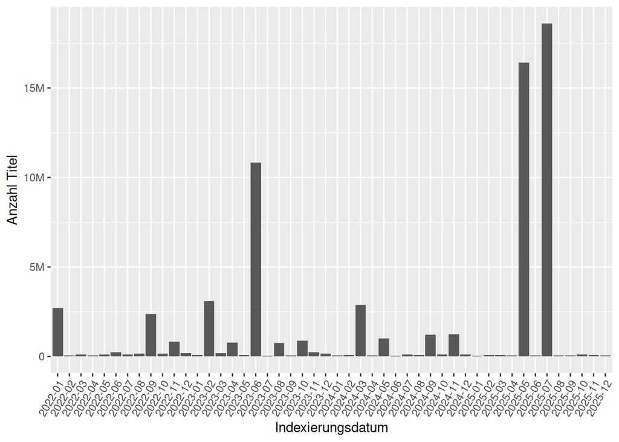

#### 2022

Gesamtanzahl an Werten: 7.127.497

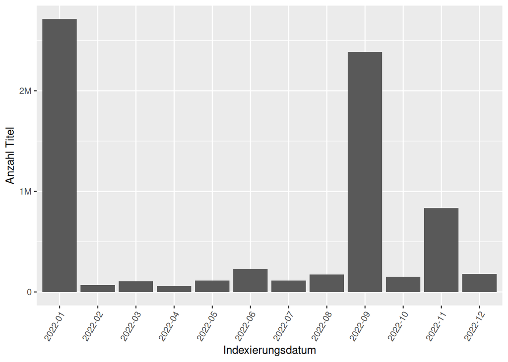

#### 2023

Gesamtanzahl an Werten: 17.182.153

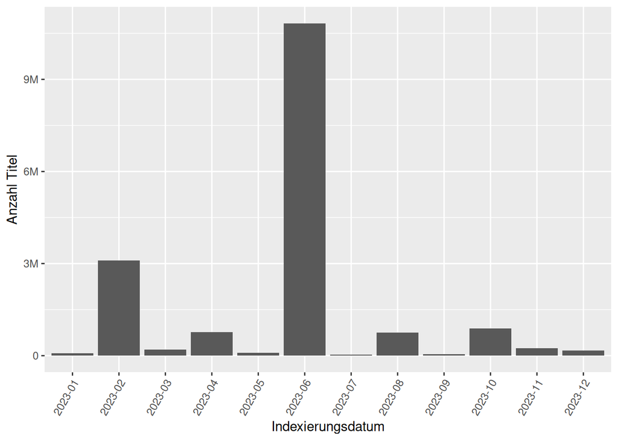

#### 2024

Gesamtanzahl an Werten: 7.044.040

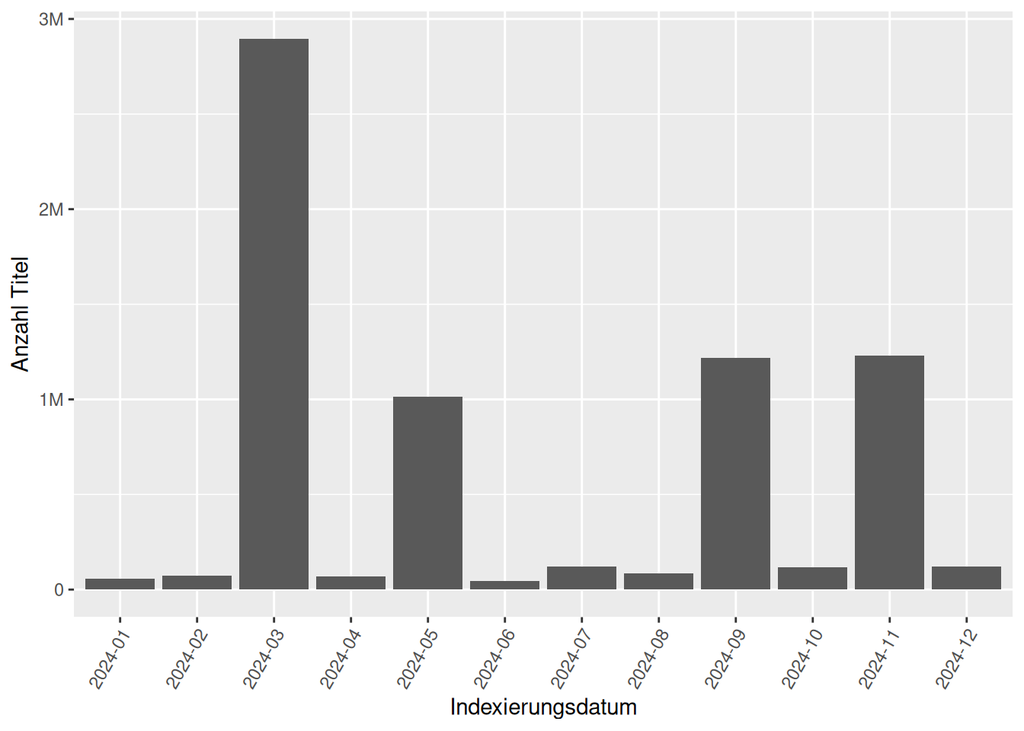

#### 2025

Gesamtanzahl an Werten: 35.688.401

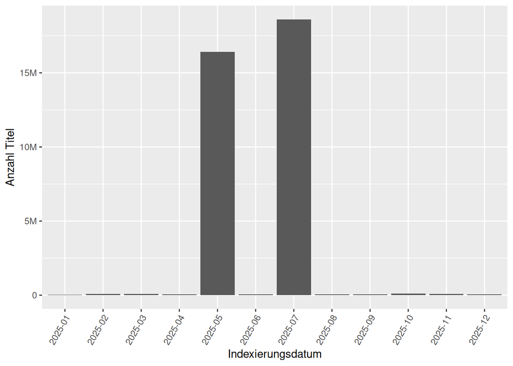

### Beispiele

**Titel** An Improved Synthesis of N-Methyl-L-glucosaminic Acid **Medientyp** E-Artikel **Indexierungsdatum** 2022-01-05 **SLUB-Katalog** ai-49-aHR0cDovL2R4LmRvaS5vcmcvMTAuMTEyNi9zY2llbmNlLjEwNC4yNjk5LjI3Ni5k

**Titel** Conflicts and mechanisms of their regulation in the Buryat society of the XVIII-XIX centuries **Medientyp** E-Artikel **Indexierungsdatum** 2022-09-12 **SLUB-Katalog** ai-49-aHR0cDovL2R4LmRvaS5vcmcvMTAuMTcyMjMvMTk5ODg2MTMvNzUvMTc

**Titel** Gdy umiera człowiek, umiera świat cały. Funeralia Lednickie. Spotkanie 18, red. W. Dzieduszycki, J. Wrzesiński, Poznań 2016 [recenzja] **Medientyp** E-Artikel **Indexierungsdatum** 2022-11-04 **SLUB-Katalog** ai-28-6effc3461b8b45b8b797b9972c476f06

**Titel** Metropolitan areas. Organizing public services in metropolitan areas. Edited by Thomas P. Murphy and Charles R. Warren. D. C. Health and Company, 125 Spring Street, Lexington, Massachusetts 02173, 1975. 245 pp. $ **Medientyp** E-Artikel **Indexierungsdatum** 2024-03-01 **SLUB-Katalog** ai-49-aHR0cDovL2R4LmRvaS5vcmcvMTAuMTAwMi9uY3IuNDEwMDY0MTExMw

**Titel** Techniques of laparoscopic myomectomy **Medientyp** E-Artikel **Indexierungsdatum** 2024-03-01 **SLUB-Katalog** ai-49-aHR0cDovL2R4LmRvaS5vcmcvMTAuMTAxNi9qLnJibW8uMjAxMC4wOS4wMTE

**Titel** Selectivity and Tax Measures: (Where) Does It Go Wrong? A Critical Assessment of the Selectivity Test Regarding Tax Measures and How To Move Forward **Medientyp** E-Artikel **Indexierungsdatum** 2024-09-17 **SLUB-Katalog** ai-49-aHR0cDovL2R4LmRvaS5vcmcvMTAuMjEzOS9zc3JuLjQ4NTAyNTI

# Lokalsystem

## Aktivierungen

### Kennzahlen

#### 2022–2025

Gesamtanzahl an Werten: 89.173

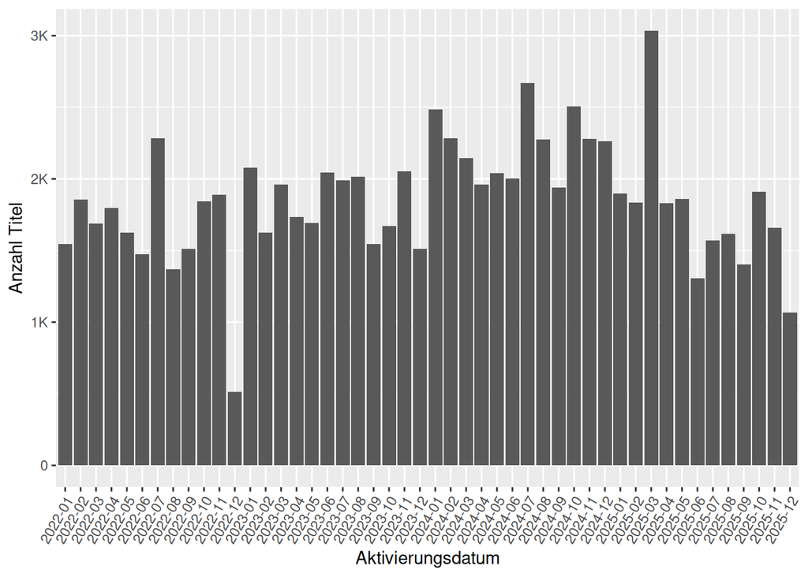

#### 2022

Gesamtanzahl an Werten: 19.396

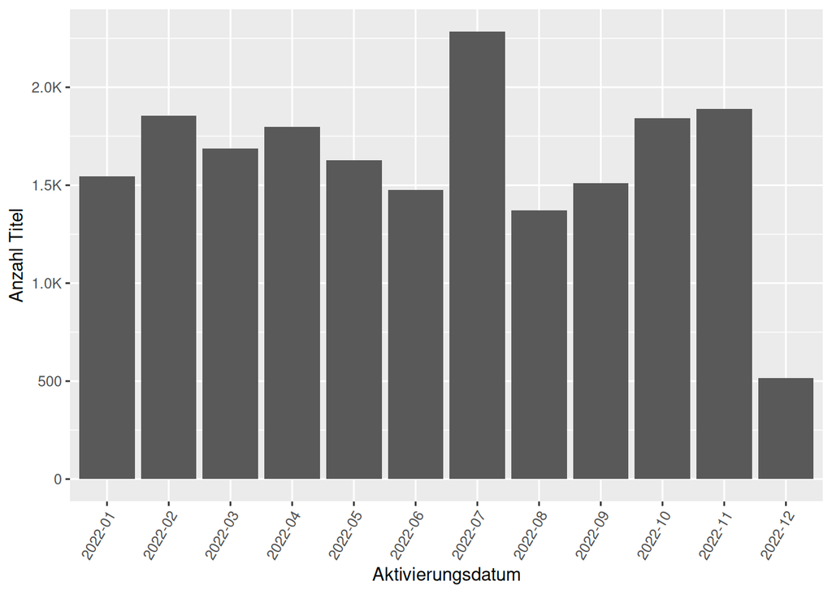

#### 2023

Gesamtanzahl an Werten: 21.923

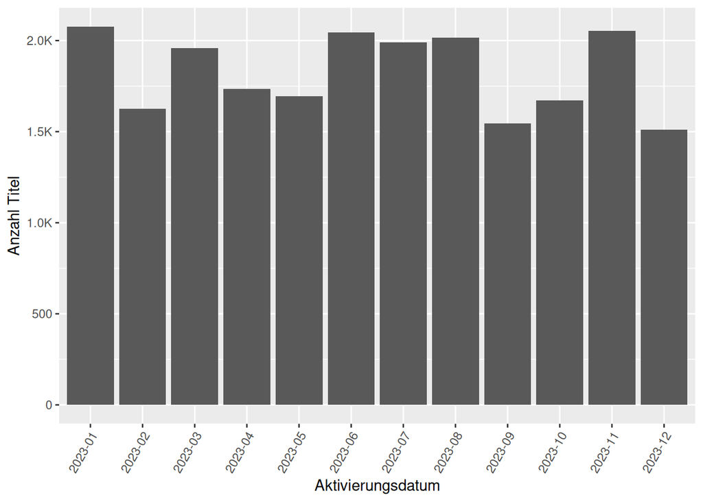

#### 2024

Gesamtanzahl an Werten: 26.854

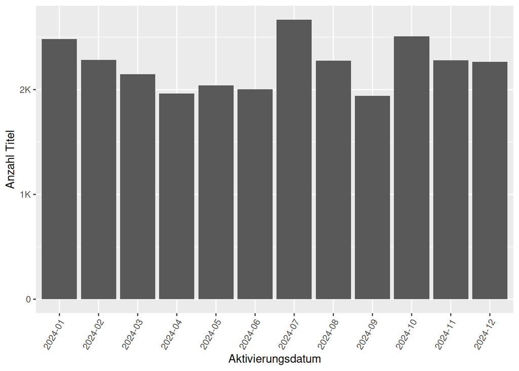

#### 2025

Gesamtanzahl an Werten: 21.000

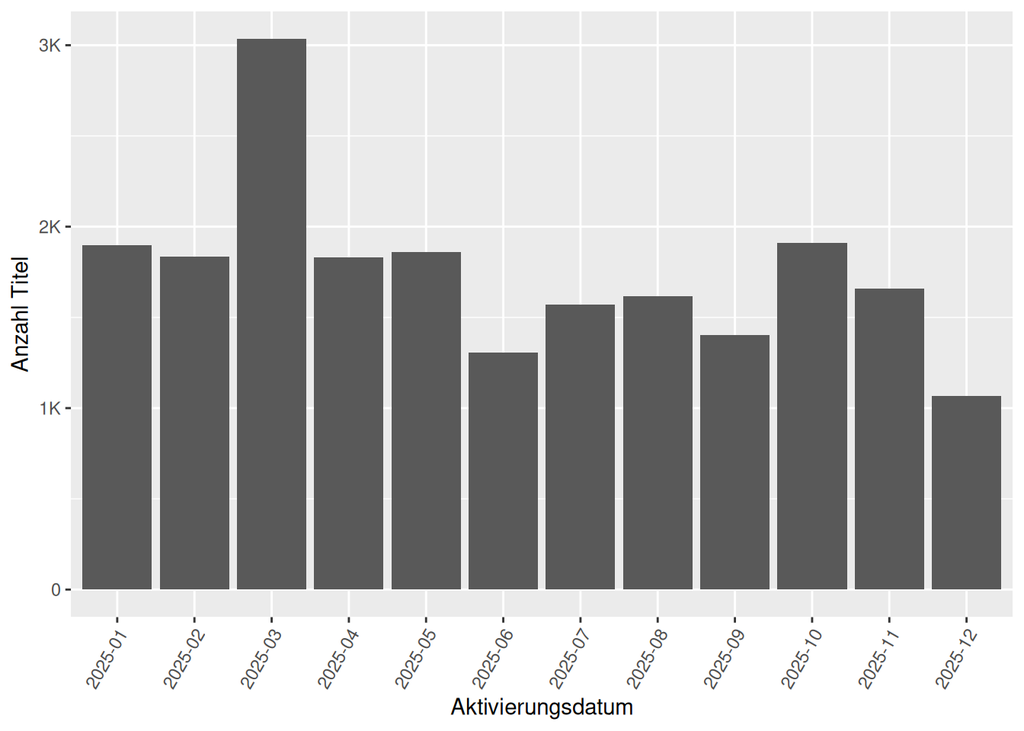

### Beispiele

**Titel** Design und Analyse von Beleuchtungsoptik auf der Basis des Phasenraumkonzeptes **Beteiligte** Rausch, Denise [VerfasserIn] ; Herkommer, Alois [AkademischeR BetreuerIn] ; Gross, H. [AkademischeR BetreuerIn] ; Universität Stuttgart **Medientyp** Buch **Erschienen** Stuttgart Institut für Technische Optik, Universität Stuttgart August 2021 **Aktivierungsdatum** 2022-02-11 **SLUB-Katalog** 0-1776179455

**Titel** Klimabewusst & glücklich: einfach bessere Entscheidungen treffen - für uns und die Umwelt **Beteiligte** Eigenbrod, Christine [VerfasserIn] ; Gesellschaft für Ökologische Kommunikation mbH **Medientyp** Buch **Erschienen** München oekom [2022] **Aktivierungsdatum** 2023-03-15 **SLUB-Katalog** 0-1820088472

**Titel** Trip mit Tropf **Beteiligte** Mark, Josephine [VerfasserIn] **Medientyp** Buch **Erschienen** Hamburg Kibitz Mai 2022 **Aktivierungsdatum** 2023-06-01 **SLUB-Katalog** 0-1780031823

**Titel** Mathematik für Bauingenieure 1 Grundlagen für das Bachelor-Studium / Kerstin Rjasanowa **Beteiligte** Rjasanowa, Kerstin [VerfasserIn] ; Carl Hanser Verlag **Medientyp** Buch **Erschienen** München Hanser [2023] **Aktivierungsdatum** 2023-08-21 **SLUB-Katalog** 0-1842117602

**Titel** Dermatologische Rezepturen: richtig verschreiben – individuell therapieren **Beteiligte** Garbe, Claus [VerfasserIn] ; Reimann, Holger [VerfasserIn] ; Georg Thieme Verlag KG **Medientyp** Buch **Erschienen** Stuttgart New York Thieme [2023] **Aktivierungsdatum** 2023-09-20 **SLUB-Katalog** 0-1851433759

**Titel** Unterrichtsgestaltung im Förderschwerpunkt geistige Entwicklung **Beteiligte** Häußler, Michael [VerfasserIn] ; W. Kohlhammer GmbH **Medientyp** Buch **Erschienen** Stuttgart Verlag W. Kohlhammer 2023 **Aktivierungsdatum** 2023-11-27 **SLUB-Katalog** 0-1843227258

**Titel** Tagebücher: das gespiegelte Ich; Museum Strauhof Literaturausstellungen, 12. Dezember 2007 - 2. März 2008 **Beteiligte** Gut, Sibylle [Sonstige Person, Familie und Körperschaft] ; Museum Strauhof **Medientyp** Buch **Erschienen** Zürich Strauhof [2007] **Aktivierungsdatum** 2024-01-24 **SLUB-Katalog** 0-1391009525

**Titel** Anleitung für Versuchsringe: 6 Vorträge gehalten auf dem Lehrgang für Versuchstechnik in Halle a. S. am 27. und 28. Juni 1924 **Beteiligte** Deutsche Landwirtschafts-Gesellschaft **Medientyp** Buch **Erschienen** Berlin Dt. Landwirtschafts-Ges. 1925 **Aktivierungsdatum** 2025-02-21 **SLUB-Katalog** 0-23257538X

**Titel** Le plurivers d’un artiste$aà partir de Bernard Koest **Beteiligte** Soulages, François [HerausgeberIn] ; Koest, Bernard [IllustratorIn] **Medientyp** Buch **Erschienen** Paris L’Harmattan [2025] **Aktivierungsdatum** 2025-05-13 **SLUB-Katalog** 0-1921710152

## Erwerbungen

### Kennzahlen

#### 2022–2025

Gesamtanzahl an Werten: 229.365

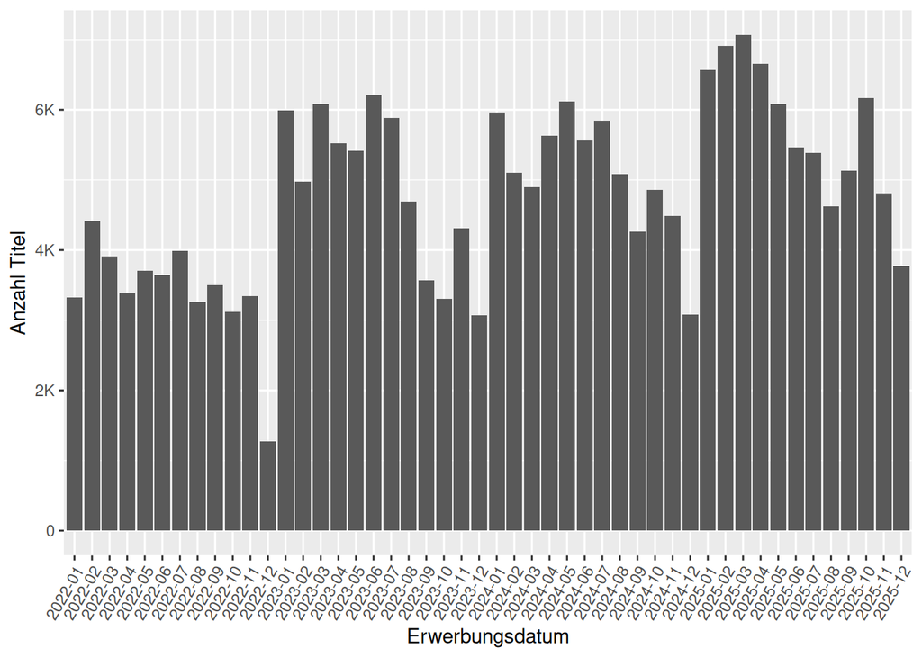

#### 2022

Gesamtanzahl an Werten: 40.861

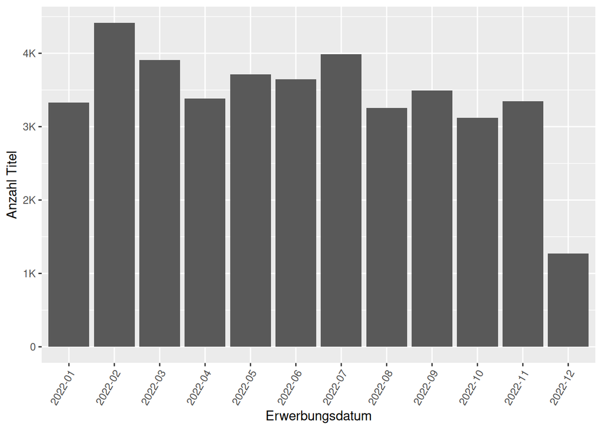

#### 2023

Gesamtanzahl an Werten: 59.009

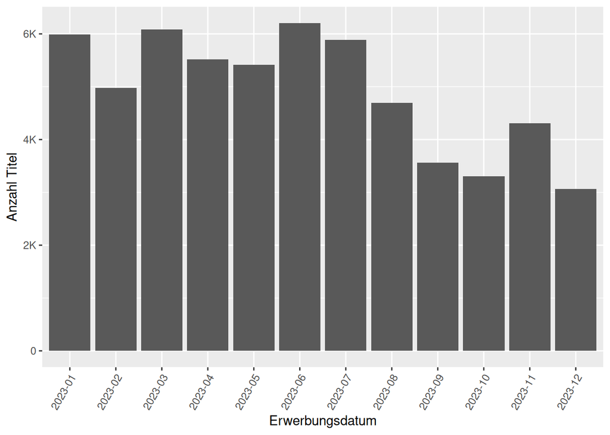

#### 2024

Gesamtanzahl an Werten: 60.873

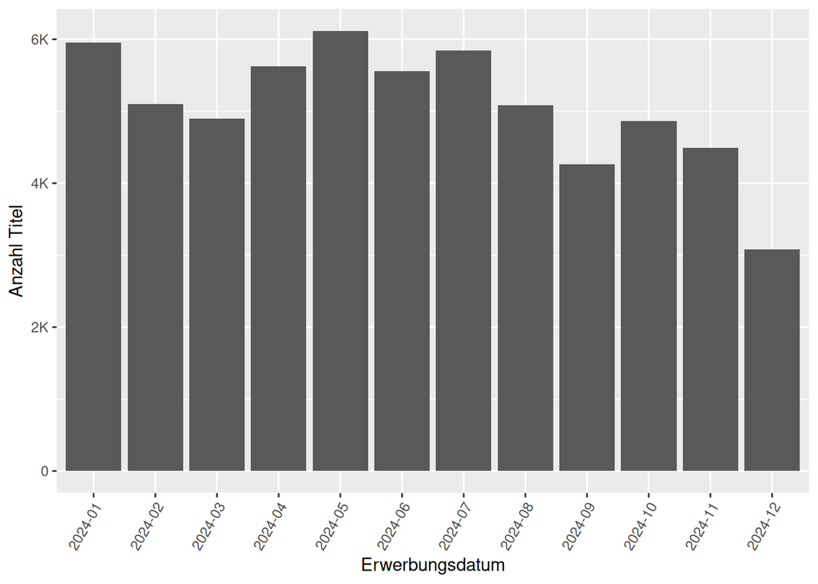

#### 2025

Gesamtanzahl an Werten: 68.622

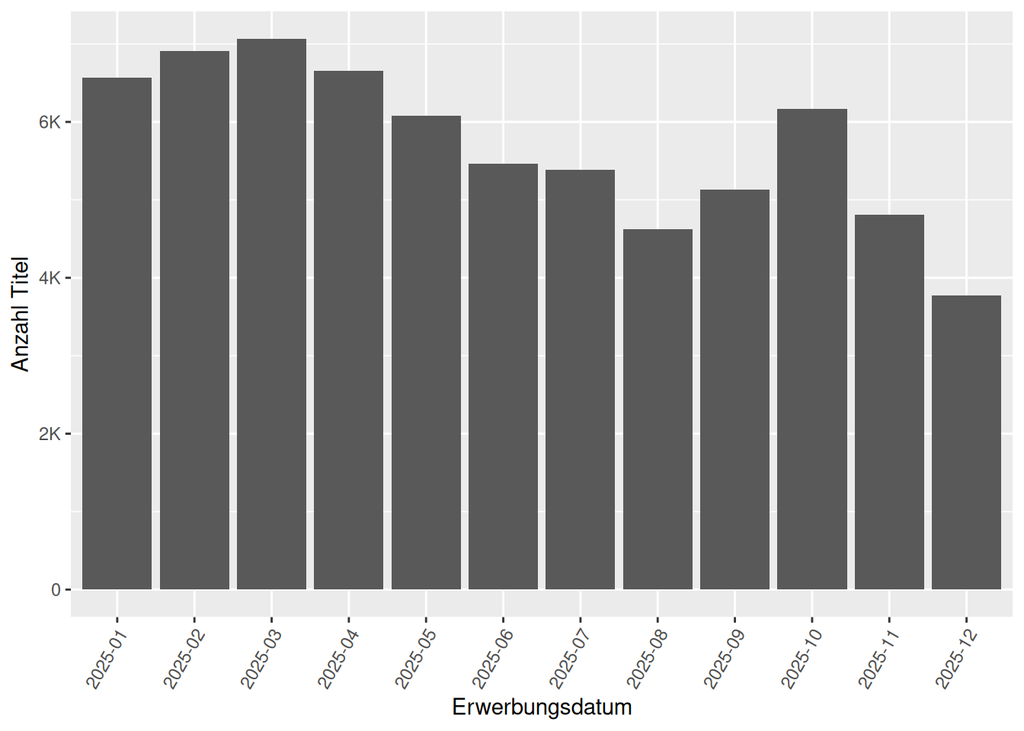

### Beispiele

**Titel** A long-term perspective on drought components in Germany **Beteiligte** Erfurt, Mathilde [VerfasserIn] ; Schanz, Heiner [AkademischeR BetreuerIn] ; Glaser, Rüdiger [AkademischeR BetreuerIn] ; Stahl, Kerstin [AkademischeR BetreuerIn] **Medientyp** Buch **Erschienen** Freiburg im Breisgau 2021 **Erwerbungsdatum** 2022-07-06 **SLUB-Katalog** 0-1772583065

**Titel** Entwerfen und Wohnen **Beteiligte** Krebs, Jan [VerfasserIn] ; Birkhäuser **Medientyp** Buch **Erschienen** Basel Birkhäuser [2021] **Erwerbungsdatum** 2022-11-24 **SLUB-Katalog** 0-1734719982

**Titel** Arbeitsrechtlicher Anspruch auf Weiterbildung in der digitalen Arbeitswelt **Beteiligte** Balkie, Patrik [VerfasserIn] **Medientyp** Buch **Erschienen** Baden-Baden Nomos 2021 **Erwerbungsdatum** 2023-04-05 **SLUB-Katalog** 0-176973015X

**Titel** Neues System der philosophischen Wissenschaften im Grundriss Band 4 Biologie, Naturgeschichte, Neurowissenschaft 2. Halbband Naturgeschichte und Neurowissenschaft / Dirk Hartmann **Beteiligte** Hartmann, Dirk [VerfasserIn] ; mentis Verlag GmbH **Medientyp** Buch **Erschienen** Paderborn Brill Mentis [2023] **Erwerbungsdatum** 2023-06-27 **SLUB-Katalog** 0-1845908945

**Titel** Nitrogen Removal in Drinking Water Treatment - A Combination of Zeolite Sorption and the Anammox-Process **Beteiligte** Eberle, Stephan [VerfasserIn] ; Stolte, Stefan [AkademischeR BetreuerIn] ; Lerch, André [AkademischeR BetreuerIn] ; Hilliges, Rita [AkademischeR BetreuerIn] ; Technische Universität Dresden **Medientyp** E-Book **Erschienen** Dresden 2023 **Erwerbungsdatum** 2023-08-09 **SLUB-Katalog** 0-1854988336

**Titel** Dat Brüden geiht üm **Beteiligte** Brinckman, John [HerausgeberIn] **Medientyp** E-Book **Erschienen** Güstrow bei Opitz & Comp. 1854 **Erwerbungsdatum** 2024-11-25 **SLUB-Katalog** 0-1909448613

**Titel** Ruth Orkin - Women **Beteiligte** Orkin, Ruth [FotografIn] ; Barth, Nadine [HerausgeberIn] ; Mouratidi, Katharina [HerausgeberIn] ; f3 - freiraum für fotografie **Medientyp** Buch **Erschienen** Berlin Hatje Cantz [2023] **Erwerbungsdatum** 2024-11-26 **SLUB-Katalog** 0-1869777530

**Titel** [Prélude] No. 2 op. 63 **Beteiligte** Arenskij, Anton Stepanovič [KomponistIn] ; P. Jurgenson **Medientyp** Band **Erschienen** Moscou Leipzig P. Jurgenson 1910 **Erwerbungsdatum** 2025-10-08 **SLUB-Katalog** 0-1942052251

**Titel** Das Fernsehen **Beteiligte** Fuchs, Franz [Verfasser:in] **Medientyp** Buch **Erschienen** München Deutsches Museum 1937 **Erwerbungsdatum** 2025-11-28 **SLUB-Katalog** 0-1165786257

**Titel** Základní mapa ČSFR 1:100 000 22-1 Blatná **Beteiligte** Tschechoslowakei **Medientyp** Blatt **Erschienen** Praha Český Úřad Geodetický a Kartografický 1992 **Erwerbungsdatum** 2025-12-05 **SLUB-Katalog** 0-1943099405